# PFAS Developmental Meta-Analysis

Alexandra Larsen

January 11, 2023

# 1 Background

The purpose of this analysis is to investigate the relationship between PFNA exposure during pregnancy and birth weight. Meta-analytic techniques were used to summarize epidemiological findings from 27 studies.

# 2 Overall Meta-Analysis

A random effects model was used to estimate the pooled effect of PFNA exposure on birth weight, capturing any between-study heterogeneity. The model employs weighted estimation with inverse-variance weights.

| Model | N | Estimate | SE | LCL | UCL | PVal | I2 | Q_PVal |
| --- | --- | --- | --- | --- | --- | --- | --- | --- |
| Overall | 27 | -32.9 | 7.2 | -47 | -18.7 | 0 | 35.93 | 0.05 |

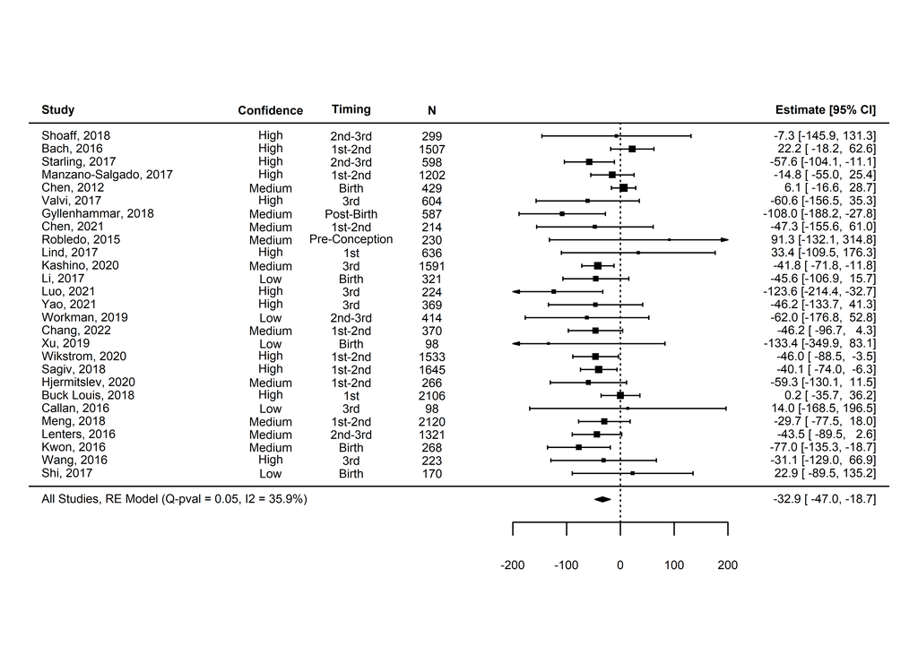

## 2.1 Leave-One-Out Analyis: Assessing heterogeneity

Results indicate that dropping Chen, 2012 leads to the lowest I2, 20.72%. Sensitivity analysis pertaining to dropping Chen, 2012 are carried out in the sections below.

| Study | estimate | se | zval | pval | ci.lb | ci.ub | Q | Qp | tau2 | I2 | H2 |
| --- | --- | --- | --- | --- | --- | --- | --- | --- | --- | --- | --- |
| Bach, 2016 | -35.80 | 7.04 | -5.08 | 0e+00 | -49.60 | -21.99 | 32.54 | 0.14 | 309.67 | 28.97 | 1.41 |
| Buck Louis, 2018 | -35.30 | 7.46 | -4.73 | 0e+00 | -49.93 | -20.68 | 36.22 | 0.07 | 403.28 | 34.28 | 1.52 |
| Manzano-Salgado, 2017 | -34.37 | 7.64 | -4.50 | 1e-05 | -49.34 | -19.40 | 38.20 | 0.04 | 456.96 | 37.56 | 1.60 |
| Sagiv, 2018 | -32.66 | 7.71 | -4.23 | 2e-05 | -47.78 | -17.54 | 37.91 | 0.05 | 466.22 | 37.37 | 1.60 |
| Shoaff, 2018 | -33.20 | 7.30 | -4.54 | 1e-05 | -47.51 | -18.88 | 38.49 | 0.04 | 422.86 | 37.27 | 1.59 |
| Starling, 2017 | -31.48 | 7.43 | -4.23 | 2e-05 | -46.05 | -16.91 | 36.79 | 0.06 | 412.91 | 35.61 | 1.55 |
| Valvi, 2017 | -32.39 | 7.32 | -4.42 | 1e-05 | -46.75 | -18.04 | 38.08 | 0.05 | 419.10 | 36.90 | 1.58 |
| Chen, 2012 | -36.20 | 6.85 | -5.28 | 0e+00 | -49.63 | -22.77 | 28.54 | 0.28 | 226.33 | 20.72 | 1.26 |
| Gyllenhammar, 2018 | -30.64 | 7.11 | -4.31 | 2e-05 | -44.58 | -16.71 | 34.57 | 0.10 | 359.73 | 33.30 | 1.50 |
| Kwon, 2016 | -30.78 | 7.23 | -4.26 | 2e-05 | -44.94 | -16.62 | 35.63 | 0.08 | 374.26 | 33.82 | 1.51 |
| Lenters, 2016 | -32.51 | 7.57 | -4.29 | 2e-05 | -47.35 | -17.66 | 38.04 | 0.05 | 448.57 | 37.51 | 1.60 |
| Meng, 2018 | -33.36 | 7.61 | -4.38 | 1e-05 | -48.27 | -18.44 | 38.55 | 0.04 | 460.42 | 38.21 | 1.62 |
| Callan, 2016 | -33.20 | 7.28 | -4.56 | 1e-05 | -47.46 | -18.93 | 38.37 | 0.04 | 419.43 | 37.14 | 1.59 |
| Li, 2017 | -32.53 | 7.46 | -4.36 | 1e-05 | -47.16 | -17.90 | 38.20 | 0.04 | 436.87 | 37.45 | 1.60 |
| Shi, 2017 | -33.76 | 7.32 | -4.61 | 0e+00 | -48.11 | -19.40 | 37.81 | 0.05 | 423.74 | 37.24 | 1.59 |
| Xu, 2019 | -32.44 | 7.23 | -4.49 | 1e-05 | -46.61 | -18.27 | 37.63 | 0.05 | 409.15 | 36.58 | 1.58 |
| Hjermitslev, 2020 | -32.09 | 7.37 | -4.35 | 1e-05 | -46.54 | -17.65 | 37.74 | 0.05 | 419.72 | 36.69 | 1.58 |
| Kashino, 2020 | -32.46 | 7.74 | -4.19 | 3e-05 | -47.63 | -17.29 | 37.49 | 0.05 | 465.69 | 36.75 | 1.58 |
| Wikstrom, 2020 | -32.27 | 7.58 | -4.26 | 2e-05 | -47.13 | -17.41 | 37.74 | 0.05 | 445.43 | 37.13 | 1.59 |
| Chen, 2021 | -32.72 | 7.32 | -4.47 | 1e-05 | -47.08 | -18.36 | 38.43 | 0.04 | 422.84 | 37.17 | 1.59 |
| Lind, 2017 | -33.55 | 7.30 | -4.60 | 0e+00 | -47.85 | -19.25 | 37.88 | 0.05 | 421.43 | 37.20 | 1.59 |
| Robledo, 2015 | -33.40 | 7.26 | -4.60 | 0e+00 | -47.64 | -19.16 | 37.49 | 0.05 | 417.59 | 37.06 | 1.59 |
| Wang, 2016 | -33.02 | 7.36 | -4.49 | 1e-05 | -47.44 | -18.59 | 38.56 | 0.04 | 428.95 | 37.46 | 1.60 |
| Luo, 2021 | -30.69 | 7.09 | -4.33 | 2e-05 | -44.59 | -16.79 | 34.15 | 0.10 | 359.40 | 33.37 | 1.50 |
| Yao, 2021 | -32.68 | 7.37 | -4.44 | 1e-05 | -47.12 | -18.24 | 38.38 | 0.04 | 427.38 | 37.30 | 1.59 |
| Workman, 2019 | -32.51 | 7.30 | -4.45 | 1e-05 | -46.82 | -18.20 | 38.20 | 0.04 | 417.80 | 36.92 | 1.59 |
| Chang, 2022 | -32.38 | 7.52 | -4.30 | 2e-05 | -47.13 | -17.64 | 37.98 | 0.05 | 441.25 | 37.34 | 1.60 |

## 2.2 Publication Bias

The Egger’s regression test did not detect a statistically significant relationship between the observed effect sizes and their standard errors (p = 0.3042), indicating no evidence of funnel plot asymmetry due to publication bias. The funnel plot is displayed below.

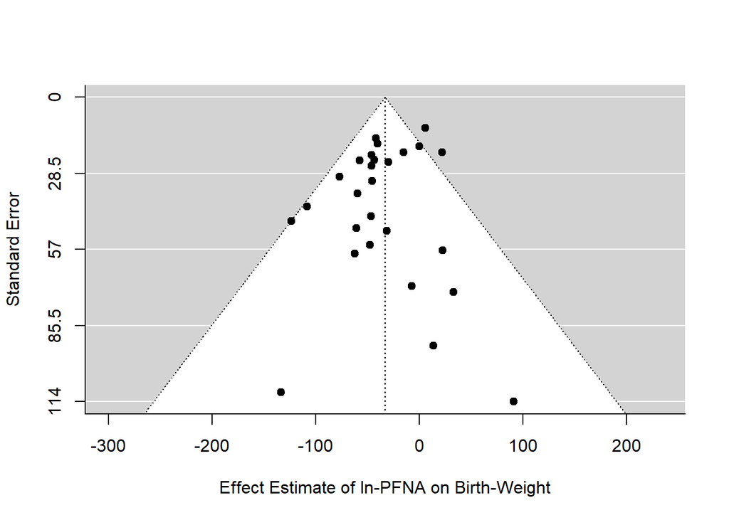

# 3 Stratified Analyses

In addition to the overall meta-analysis, the studies are also examined according to the following stratification: study confidence, sample timing.

## 3.1 Study Confidence

In this section, the studies are examined by confidence levels - low, medium, high, or medium and high combined. Pooled effects are calculated and statistical differences across strata are considered.

| Model | N | Estimate | SE | LCL | UCL | PVal | I2 | Q_PVal |
| --- | --- | --- | --- | --- | --- | --- | --- | --- |
| High | 12 | -28.0 | 10.8 | -49.0 | -6.9 | 0.01 | 38.80 | 0.11 |
| Medium | 10 | -39.0 | 11.6 | -61.8 | -16.3 | 0.00 | 48.09 | 0.03 |
| Low | 5 | -36.9 | 23.5 | -82.9 | 9.1 | 0.12 | 0.00 | 0.66 |
| High+Medium | 22 | -32.9 | 7.7 | -48.0 | -17.8 | 0.00 | 42.22 | 0.02 |

Results from the hypothesis test results for any significant differences across strata:

- For all three levels, High, Medium and Low: p = 0.7733.
- For High + Medium and Low: p = 0.8718.

## 3.2 Sample Timing

In this approach, the strata have the following definitions:

- Early: first trimester only, mixture of first and second trimester.
- Late: second trimester only, mixture of second and third trimester, third trimester only.
- Post: at or after birth.

Pooled effects are calculated and statistical differences across strata are considered.

| Model | N | Estimate | SE | LCL | UCL | PVal | I2 | Q_PVal |
| --- | --- | --- | --- | --- | --- | --- | --- | --- |
| Early | 11 | -22.0 | 9.2 | -40.1 | -4.0 | 0.02 | 25.91 | 0.26 |
| Late | 10 | -48.4 | 9.9 | -67.7 | -29.0 | 0.00 | 0.00 | 0.91 |
| Post | 6 | -42.9 | 23.0 | -88.0 | 2.2 | 0.06 | 63.08 | 0.01 |

Results from the hypothesis test for any differences across strata: p = 0.1407.

# 4 Meta-Regression

To further examine the impact of sampling on the relationship between PFNA and birth weight, a continuous approach for the analysis of sample timing is employed. A meta-regression on a measure of centrality of sample timing is carried out and a pooled effect is presented. Measures of centrality include mean, median, range midpoints, weighted mean of means/medians/midpoints and exact numbers. The results estimate that the effect of PFNA on birth weight changes by -0.8642 g per unit increase in the measure of centrality of gestational age at sample timing (95% CI: -2.05, 0.32).

# 5 Sensitivity Analyses

## 5.1 Leave-One-Out Sensitivity Analysis

In this section, the robustness of the overall, confidence and sampling timing meta-analyses is examined with regards to dropping the study identified by the Leave-One-Out analysis above. Each analysis is run without the study, Chen, 2012.

| Model | N | Estimate | SE | LCL | UCL | PVal | I2 | Q_PVal |
| --- | --- | --- | --- | --- | --- | --- | --- | --- |
| Overall | 26 | -36.2 | 6.9 | -49.6 | -22.8 | 0 | 20.72 | 0.28 |
| Medium | 9 | -47.8 | 9.1 | -65.6 | -30.1 | 0 | 0.00 | 0.71 |
| High+Medium | 21 | -36.5 | 7.3 | -50.9 | -22.1 | 0 | 27.03 | 0.16 |
| post | 5 | -64.5 | 17.9 | -99.5 | -29.5 | 0 | 0.00 | 0.36 |

## 5.2 Two-Strata Approach for the Analysis of Sample Timing

In this section, the three-strata approach is compared to a two-strata approach, wherein the “late” and “post” strata are collapsed into a single “late+post” strata. Pooled effects are calculated and statistical differences across strata are considered.

| Model | N | Estimate | SE | LCL | UCL | PVal | I2 | Q_PVal |
| --- | --- | --- | --- | --- | --- | --- | --- | --- |
| Late+Post | 16 | -44.5 | 10.9 | -65.9 | -23 | 0 | 40.02 | 0.05 |

Results from the hypothesis test for any differences between “early” and “late+post” strata: p = 0.1171.

## 5.3 Log-based studies only

This analysis examines the sensitivity of the overall pooled estimate to using only the 24 log-based studies, excluding those needed re-expression, i.e., Bach, 2016, Sagiv, 2018, Shoaff, 2018.

| Model | N | Estimate | SE | LCL | UCL | PVal | I2 | Q_PVal |
| --- | --- | --- | --- | --- | --- | --- | --- | --- |
| Overall | 24 | -36.2 | 7.6 | -51.2 | -21.3 | 0 | 31.78 | 0.1 |

## 5.4 Random vs. fixed effect analyses

| Model | N | Estimate | SE | LCL | UCL | PVal | I2 | Q_PVal |
| --- | --- | --- | --- | --- | --- | --- | --- | --- |
| Random | 27 | -32.9 | 7.2 | -47.0 | -18.7 | 0 | 35.93 | 0.05 |
| Fixed | 27 | -26.8 | 5.1 | -36.8 | -16.8 | 0 | 32.58 | 0.05 |

## 5.5 Re-expression to Natural Scale

In this section, each model is re-run using data re-expressed to the natural scale as a sensitivity test to the findings on the log-scale.

| Model | N | Estimate | SE | LCL | UCL | PVal | I2 | Q_PVal |
| --- | --- | --- | --- | --- | --- | --- | --- | --- |
| Overall | 27 | -37.0 | 10.2 | -56.9 | -17.0 | 0.00 | 50.74 | 0.00 |
| High | 12 | -37.7 | 15.9 | -69.0 | -6.5 | 0.02 | 44.04 | 0.04 |
| Medium | 10 | -35.1 | 13.9 | -62.4 | -7.9 | 0.01 | 60.94 | 0.00 |
| Low | 5 | -163.5 | 104.2 | -367.8 | 40.8 | 0.12 | 0.00 | 0.66 |
| High+Medium | 22 | -35.4 | 10.1 | -55.1 | -15.7 | 0.00 | 54.56 | 0.00 |
| Early | 11 | -25.7 | 12.6 | -50.4 | -1.1 | 0.04 | 29.39 | 0.13 |
| Late | 10 | -49.0 | 13.7 | -75.9 | -22.1 | 0.00 | 10.82 | 0.30 |
| Post | 6 | -186.3 | 95.4 | -373.2 | 0.6 | 0.05 | 66.25 | 0.00 |
| Late+Post | 16 | -72.7 | 22.6 | -117.1 | -28.3 | 0.00 | 77.96 | 0.00 |

## 5.6 Additional Sensitivity Analyses

### 5.6.1 Kwon, 2016

For PFNA, sensitivity testing was required regarding the study, Kwon, 2016, which did not report the log base of their estimates. Firstly, the medium confidence strata is examined for sensitively to including Kwon. Estimates are provided below.

| Model | N | Estimate | SE | LCL | UCL | PVal | I2 | Q_PVal |
| --- | --- | --- | --- | --- | --- | --- | --- | --- |
| Medium w/o Kwon, 2016 | 9 | -34.6 | 11.8 | -57.8 | -11.5 | 0 | 45.92 | 0.04 |

Additionally, sensitivity was explored with regards to different log bases of the Kwon, 2016 study. Estimates are provided below.

| Model | N | Estimate | SE | LCL | UCL | PVal | I2 | Q_PVal |
| --- | --- | --- | --- | --- | --- | --- | --- | --- |
| log_e | 27 | -32.9 | 7.2 | -47.0 | -18.7 | 0 | 35.93 | 0.05 |
| log_2 | 27 | -33.0 | 7.4 | -47.5 | -18.6 | 0 | 36.50 | 0.04 |
| log_10 | 27 | -30.6 | 6.6 | -43.6 | -17.6 | 0 | 32.29 | 0.09 |

### 5.6.2 High confidence stratified analysis

| Model | N | Estimate | SE | LCL | UCL | PVal | I2 | Q_PVal |
| --- | --- | --- | --- | --- | --- | --- | --- | --- |
| Early | 6 | -14.6 | 12.1 | -38.4 | 9.2 | 0.23 | 44.33 | 0.13 |
| Late | 6 | -59.1 | 16.3 | -91.0 | -27.1 | 0.00 | 0.00 | 0.72 |

Results from the hypothesis test for any differences across strata: p = 0.0287.

# 6 Supplemental

## 6.1 Figure for pooled effect estimates

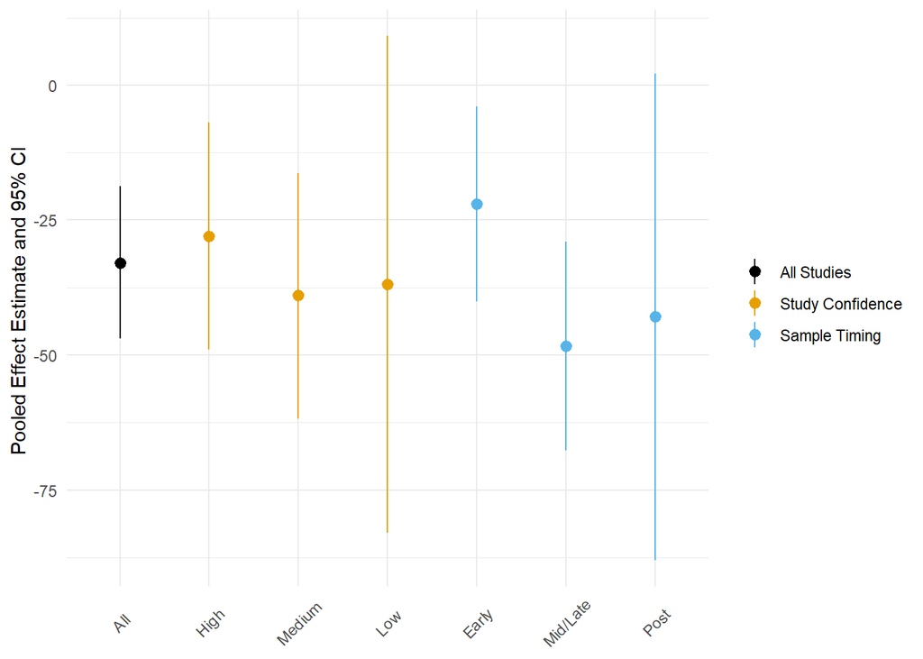